[Home](https://jenna-tb-ekwealor.github.io/Biostatistics_laboratory/)

[← Previous Chapter](https://jenna-tb-ekwealor.github.io/Biostatistics_laboratory/Ch2.html)

[Next Chapter →](https://jenna-tb-ekwealor.github.io/Biostatistics_laboratory/Ch4.html)

# Visualizing data

## Chapter 3

**Today’s investigation.** Displaying data using appropriate *graphing tools* is one of the most important jobs we have as scientists. Good *data visualization* brings us the opportunity to show the newly discovered trends and relationships between variables. That is, through good data visualization, we may reach different audiences and send a clear message home. Today, we will learn how to generate graphs parting from the type of data we have and the research question we want to answer using two different datasets of marine invertebrates from CSULB Marine Ecology Lab and of microbial genomics from CSULB Comparative Microbial Genomics Lab.

### Introduction

In this lab, we will generate multiple graphs to identify good data visualization practices, which include making data displays that are clear, easy-to-interpret, and unbiased. When we carry out an experiment, a field study, or a computer-based analysis, we are evaluating variables. These variables can take different forms; they can be *categorical* (e.g., males vs females; climatic seasons) or *numerical* (e.g., weight; temperature), and our main interest may be to show a *range of values for one variable* or an *association between two variables*. So, how do we choose between the many data visualization tools available?

Today, we will explore different biological datasets in order to generalize on good data visualization practices. Specifically, we will practice how to identify variable types and explore effective ways to display such variables using anatomical data from the *Uca pugnax* crab collected by Dr. Bengt Allen from CSULB Marine Ecology Lab and microbial genomics data extracted from the public database PATRICbrc by Dr. Renaud Berlemont from CSULB Comparative Microbial Genomics Lab (Figure 1). R programming language offers multiple ways to carry out high-quality graphs, however, it is up to us to decide which one to use for our data. So, let’s first explore the different datasets and decide the most appropriate graphs to display them.

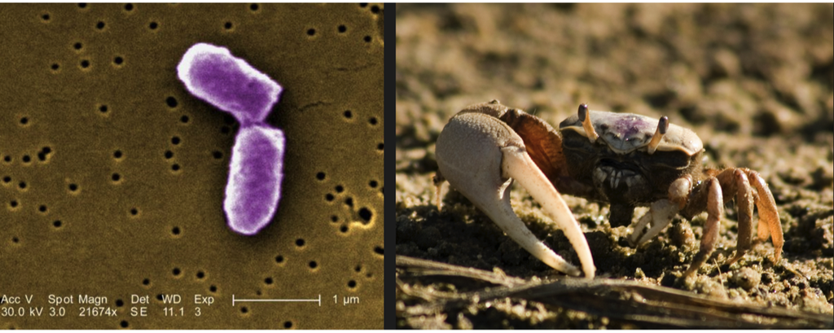

Figure 1. Left panel: *Escherichia coli* under a high magnification of 21674X. Image: Centers for Disease Control and Prevention. Right panel: *Uca* species. Image: Dominique DeLambert

**Upon completion of this lab, you should be able to:**

- Differentiate between variable types;
- Identify appropriate data visualizations given a set of variables;
- Read and interpret graphs.

**References:**

- [Pathosystems Resource Integration Center (PATRIC)](https://patricbrc.org)
- [Fundamentals of Data Visualization](https://serialmentor.com/dataviz/)
- [Cookbook for R](http://www.cookbook-r.com/Graphs/)

### Worked example

To get started, let’s remind ourselves the different variable types:

- categorical - describes membership in a category or group. These variables do not correspond to a numerical magnitude.
- numerical - describes a quantitative measure. These variables are numbers, and thus have magnitude in a numerical scale. Numerical variables can also be continuous or discrete. A *continuous numerical variable* can take any value within a range, while a *discrete numerical variable* can take integer values only.

When we are exploring associations between variables, they are also categorized into explanatory or response variables:

- explanatory - the variable that predicts or affects the other. This variable is also known as the *independent* variable.
- response - the variable predicted or affected by the explanatory variable. This variable is also known as the *dependent* variable.

Let’s explore three different visualizations for the same temperature data and how they are useful to explore three different research questions.

### Visualization 1: How does site-specific temperature change across time?

A common way to display trends in time, such as temporal changes in temperature, is through *line graphs*. Usually, we display one data point of the *y*-axis (response=temperature) per each data point of time (explanatory = days), which is displayed in the *x*-axis. In this way, adjacent points along the *x*-axis are connected by a line, displaying the temporal trend (here labeled by month, Figure 2).

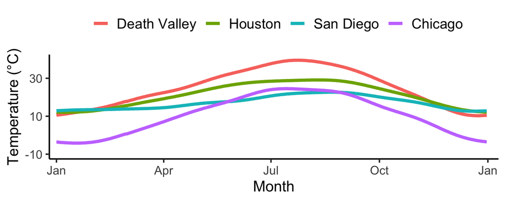

Figure 2. Daily temperature normals for four locations in the U.S. Data source: NOAA.

**Interpretation.** From this line graph, we can observe general patterns in temperature across time; cooler temperatures during winter months and warmer temperatures during summer months. We can also observe site-specific patterns because the data also includes a third categorical variable; *location*. According to the displayed data, Chicago has more variability in daily temperature normals, while San Diego has less variability. This simple data visualization exercise opens up more interesting questions concerning latitudinal patterns in temperature and the drivers of variability in such latitudinal gradient.

### Visualization 2: What month exhibits the highest mean temperature variation across sites?

Another visual technique that we can use to show the magnitude and pattern of a phenomenon are *heat maps* (Figure 3). In this case, we display a variation in color that corresponds to the magnitude of the response variable. This serves as a visual cue to the reader about how the variable changes and/or is clustered over time.

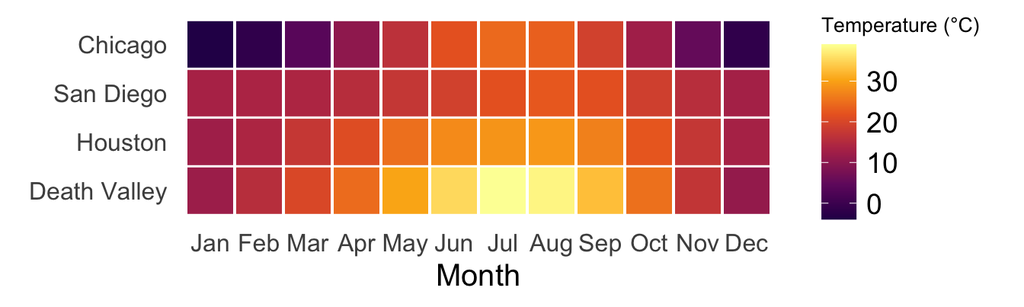

Figure 3. Monthly normal mean temperatures for four locations in the U.S. Data source: NOAA

### Visualization 3: How periodic is daily temperature across sites?

A last visualization that is useful for periodic data, such as daily temperature across years, are *polar coordinates*. Here, data values at one end of the scale can be logically joined to data values at the other end. Let’s consider our explanatory variable; days. December 31st is the last day of the year, but it is also one day before the first day of the year. If we want to show how some quantity varies over the year, we can use polar coordinates with the angle coordinate specifying each day (Figure 4). Here, the radial distance from the center point indicates the daily temperature and the days of the year are arranged counter-clockwise starting with January. By plotting the temperature normals in a polar coordinate system, we emphasize the cyclical property they have.

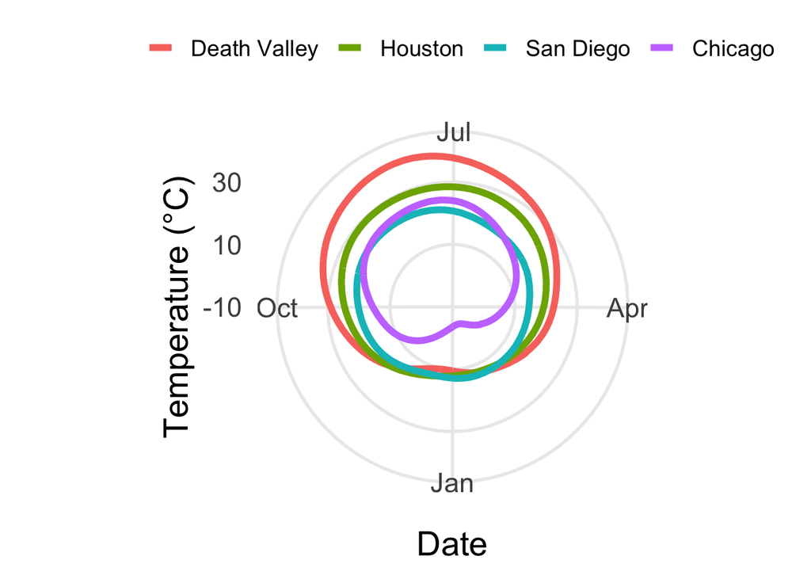

Figure 4. Daily temperature normals for four selected locations in the U.S. Data source: NOAA

**Interpretation.** From this polar coordinate, we can address directly the repetitiveness and thus periodicity that temperature has through time. If this was not the case, we would not observe circles in this plot. Similar to Figure 2 and Figure 3, we can also see that Death Valley presents the warmest temperatures during summer, while Chicago exhibits the coldest temperatures during winter. We can also see that Death Valley, Houston and San Diego present similar temperatures during winter.

Materials and Methods

- R and RStudio
- R package *tidyverse* (which includes *ggplot2*)
- uca.csv
- micro.txt

Today’s activity *Visualizing data* is organized into five main exercises using the relatively small *Uca* crab dataset followed by a challenge exercise using the larger microbial genomics dataset.

Visualizing data

### 1. Import the data

Import both datasets to RStudio and check them out. **Don’t forget to use the metadata file for reference.**

```r
# importing the uca data
uca <- read.csv("uca.csv", header = TRUE, stringsAsFactors = TRUE)
View(uca)

# importing the microbial genomics data
micro <- read.table("micro.txt", stringsAsFactors = TRUE)
View(micro)
```

Note that "View()" is convenient in RStudio but it will not work in a knitted document (and will sometimes cause Knit failure). It is advised that you delete or comment out this line prior to knitting.

### *Question Set 1*

1. **1a.** *How many variables and observations does “uca” have?* **Hint:** review past Rmd scripts!
2. **1b.** *How many variables and observations does “micro” have?*

Info-Box!

To plot the data, we will use R package *ggplot2* (included with *tidyverse*). In and .Rmd document, your plots will appear under your code chunk. In a regular R script, you'll see them under “Plots” in the bottom right window of RStudio. In *ggplot2*, we use the function `ggplot()` to generate the graphs. The basic template for ggplots is

```
 ggplot(data =
DATA, mapping = aes(MAPPINGS)) + GEOM_FUNCTION(),
```

where DATA is our data, MAPPINGS are the *x*-axis and *y*-axis variables, and GEOM_FUNCTION is the graph type. *ggplot2* offers many different geoms, including:

- **geom_bar()**, for bar graphs;
- **geom_histogram()**, for histograms;
- **geom_point()**, for scatter plots;
- **geom_boxplot()**, for boxplots;
- **geom_line()**, for trend lines and time series.

We will explore some ggplots, but many free-online resources exist for your reference such as the [Cookbook for R](http://www.cookbook-r.com/Graphs/).

### 2. Displaying data for one variable

To examine data for a single variable we use **frequency distributions** which are the number of occurrences of each value in the data.

**A. When displaying categorical data, use a bar graph**.

A bar graph uses the *height* of the bars to display the frequency distribution of categorical variables. Say we are interested in exploring the claw size distribution of the *Uca* crab. Are there size classes with more representation in the population? To answer this question, we can generate a frequency distribution for the different claw size classes (categorical variables; i.e., small, medium, large) using a bar graph. As we did in Chapter 1, before you use a package for the first time you need to install it, then you should load it using **library()** in every subsequent R session as needed.

```r
# load tidyverse package (install in console if you haven't already done so)
library(tidyverse)

# checking the first rows of the dataframe
head(uca)

# frequency of claw size classes
p1 <- ggplot(data = uca, aes(x = claw_size)) +
  geom_bar()
p1
```

A good practice is to order the bars by magnitude as it helps the reader to find important patterns in the data. Let’s reorder the frequency bars from highest magnitude to lowest. For this, we first need to estimate a frequency table for claw size classes using **table()**.

```r
# frequency table of claw size classes
freq_t <- table(uca$claw_size)
freq_t

# converting freq_t into a data frame to plot it
freq_t <- as.data.frame(freq_t)
freq_t

# reordering the bars per magnitude using the new dataframe
p1 <- ggplot(data = freq_t, aes(x = reorder(Var1, -Freq), y = Freq)) +
   geom_bar(stat = "identity")
p1
```

Finally, let’s add some important aesthetics to *p1*.

```r
# adding y- and x-axis labels using ylab() and xlab()
p1 <- ggplot(data = freq_t, aes(x = reorder(Var1, -Freq), y = Freq)) +
  geom_bar(stat = "identity") +
  ylab("Number of individuals") +
  xlab("Claw size class")
p1

# deleting the background color using theme_classic()
p1 <- ggplot(data = freq_t, aes(x = reorder(Var1, -Freq), y = Freq)) +
  geom_bar(stat = "identity") +
  ylab("Number of individuals") +
  xlab("Claw size class") +
  theme_classic()
p1

# increasing the font size to "18"
p1 <- ggplot(data = freq_t, aes(x = reorder(Var1, -Freq), y = Freq)) +
  geom_bar(stat = "identity") +
  ylab("Number of individuals") +
  xlab("Claw size class") +
  theme_classic(18) # you can use any number here
p1
```

Note: The value in theme_classic() controls the base text size of the figure. When knitting to PDF, the final appearance depends on the figure dimensions (fig.width and fig.height). Adjust this value as needed so axis labels and text are readable in the rendered PDF.

### *Question Set 2*

1. **2a.** *What type of variable is “claw_size”?*
2. **2b.** *Are claw size classes represented equally in the population?*
3. **2c.** *Which size class is least represented in the population?*

Challenge 1: Say we are interested in exploring biases in available microbial sequenced genomes. Are there particular microbes that have been sequenced by scientists more than others? To answer this question we can generate a frequency distribution for different microbial classifications (categorical variables; e.g., kingdom, phylum) using also bar graph. **Reproduce Figure 5 below showing the number of sequenced genomes per kingdom** (categorical variables; i.e., Archaea, Bacteria, Viruses) using *p1* as example.

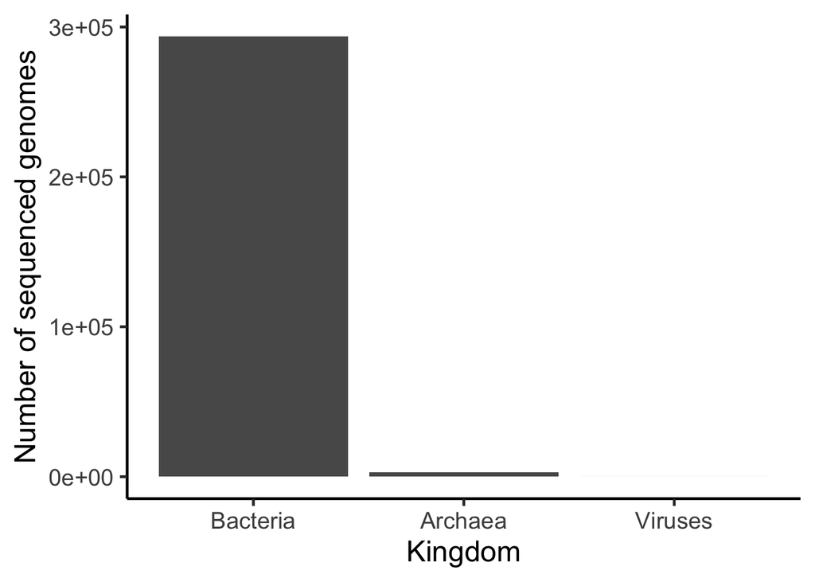

**B. When displaying numerical data, use a histogram**.

In contrast to bar graphs, histograms use the *area* of the bars to display the frequency distribution of numerical variables. In this way, histograms split the data values into intervals or **bins**, showing the shape of frequency distributions.

Let’s explore the claw length distribution of the *Uca* crab.

```r
# histogram for claw length distribution
p2 <- ggplot(uca, aes(x = claw_length)) +
  geom_histogram()
p2

# changing the bin width
p2 <- ggplot(uca, aes(x = claw_length)) +
  geom_histogram(binwidth = 2)
p2

# adding aesthetics
p2 <- ggplot(uca, aes(x = claw_length)) +
  geom_histogram(binwidth = 2) +
  ylab("Number of individuals") +
  xlab("Claw length (mm)") +
  theme_classic()
p2
```

### *Question Set 3*

1. **3a.** *What type of variable is “claw_length”?*
2. **3b.** *What happens as you increase the bin width?*
3. **3c.** *What shape does the frequency distribution of claw length have?*

Challenge 2: Now, let’s say we are interested in exploring the genome length distribution of the available microbial sequenced genomes. **Reproduce Figure 6 below showing the microbial genome length distribution across kingdoms** using *p2* as an example. **Hint:** check the variable “genome_length” in “micro” and think about an appropriate bin width.

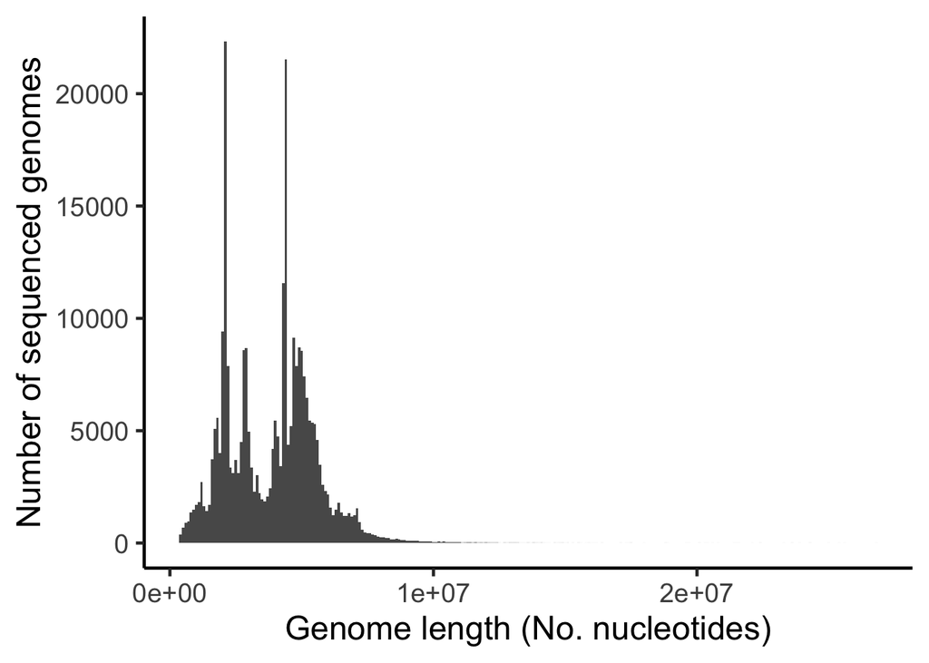

### 3. Displaying associations between two variables

Here, we are interested in graphing two different variables to explore associations between them, or a difference between groups.

**A. When displaying categorical data, use a mosaic plot**.

A mosaic plot is similar to a bar graph but bars within groups are stacked on top of one another.

Let’s explore associations between claw size class and crab mass using a mosaic plot.

```r
# mosaic plot for claw size and crab body mas
p3 <- ggplot(data = uca, aes(x = claw_size, fill = mass_class)) +
  geom_bar() +
  ylab("Number of individuals") +
  xlab("Claw size class") +
  theme_classic()
p3
```

### *Question Set 4*

1. **4a.** *What type of variable are “claw_size” and “mass_class”?*
2. **4b.** *What associations between claw size and crab body mass can you infer from the graph?*
3. **4c.** *What distribution of mass classes would you expect in a population of crabs with large claw size?*

Challenge 3: Say we are interested in exploring associations between available sequenced genomes per kingdom and phylum. **Reproduce Figure 7 below showing the number of microbial sequenced genome per kingdom and phylum** using *p3* as an example.

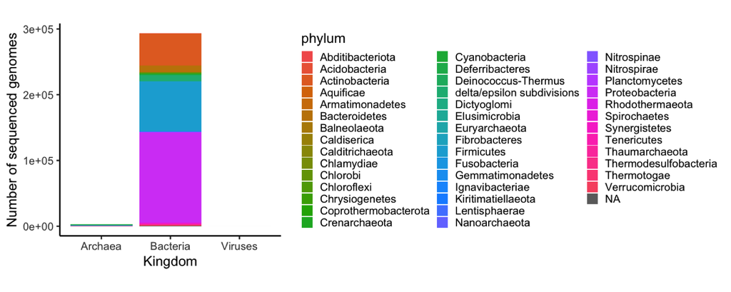

Figure 7. Microbial sequenced genomes per kingdom and phylum. Data source: PATRICbrc dataset.

**B. When displaying numerical data, use scatter plots**.

A scatter plot is used whenever we want to explore the association between two numerical variables. Here, the explanatory variable is positioned in the *x*-axis, while the response variable is positioned in the *y*-axis.

Let’s explore the association between *Uca*’s claw length and claw mass using **geom_point()**.

```r
# scatter plot for claw length and claw mass
p4 <- ggplot(uca, aes(x = claw_mass, y = claw_length)) +
  geom_point()
p4

# differentiating by mass class adding the aesthetic of color=mass_class
p4 <- ggplot(uca, aes(x = claw_mass, y = claw_length, color = mass_class)) +
  geom_point()
p4

# adding all aesthetics
p4 <- ggplot(uca, aes(x = claw_mass, y = claw_length, color = mass_class)) +
  geom_point() +
  ylab("Claw length (mm)") +
  xlab("Claw mass (g)") +
  theme_classic()
p4
```

### *Question Set 5*

1. **5a.** *What type of variable are “claw_mass”, “claw_length”, and “mass_class”?*
2. **5b.** *What is the response variable and the explanatory variable?*
3. **5c.** *What associations can you infer from the graph?*

Challenge 4: Say we are interested in exploring whether longer microbial genomes are associated to a larger number of genes in the genome. **Reproduce Figure 8 below showing the association between the number of genes and the genome length for microbes across phylum** using *p4* as an example. **Hint:** You may plot the data without a legend by adding **theme(legend.position = “none”)** to the plot codes. Be aware of the *x*-axis!

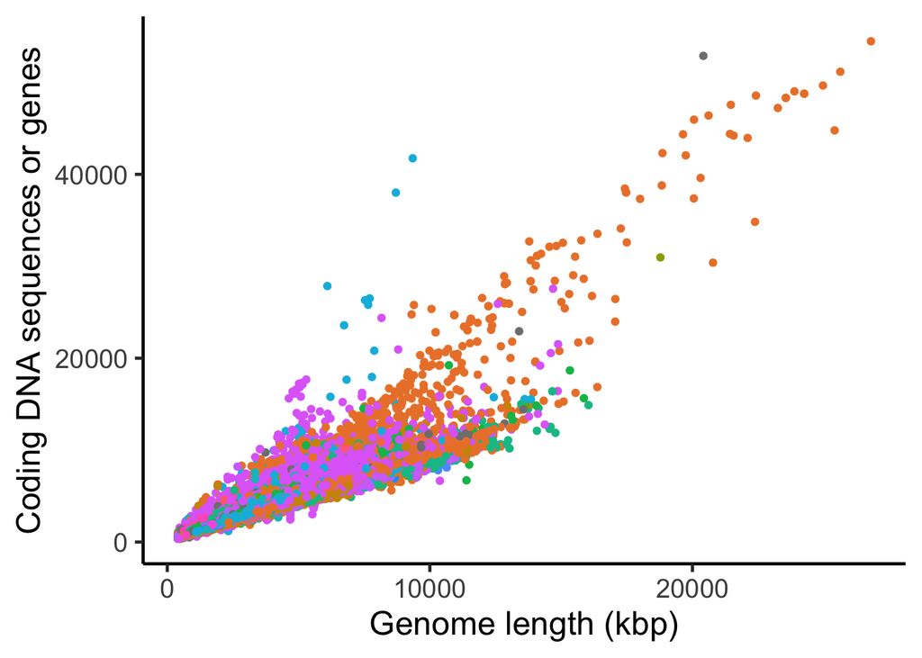

Figure 8. Number of genes as a function of genome length (kbp). Data source: PATRICbrc dataset.

**C. When displaying numerical and categorical data, use box plots**.

A box plot uses lines and rectangular boxes to display a summary of the frequency distribution of the variable of interest. Specifically, box plots show the median, quartiles, range, and extreme measurements of the data (Figure 9). Let’s first review the definitions of each component in the summary:

- *median* - the middle measurement of the observations. That is, half of the observations are located below the median and the other half are located above the median.
- *quartile* - each of four equal groups into which the data can be divided according to the distribution of values. That is, one-fourth or 25% of the data lies below the *first quartile* and one-fourth or 25% of the data lies above the *third quartile*.
- *range* - the difference between the maximum and minimum value.
- *extreme measure* - a data point that differs significantly from the rest.

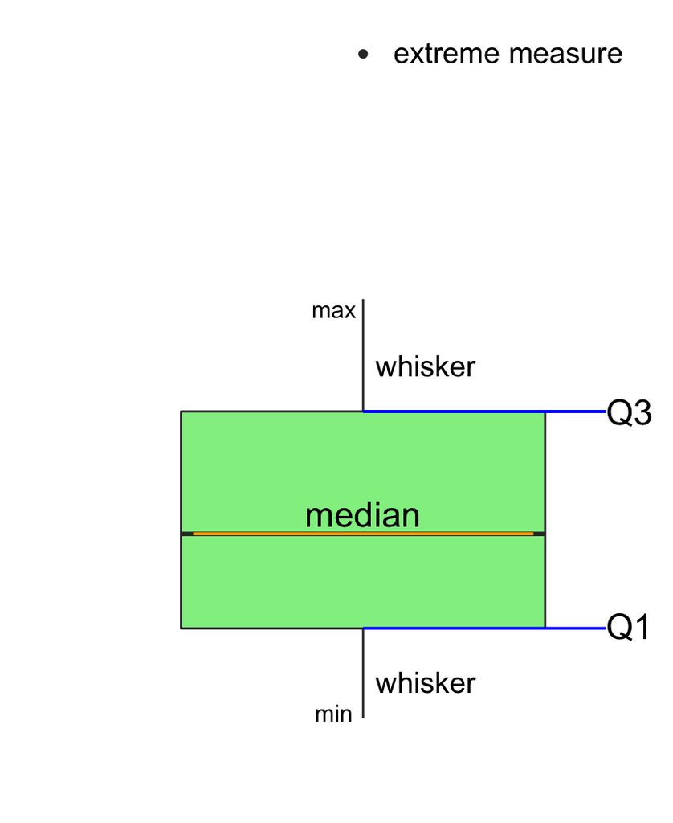

Figure 9. Anatomy of a box plot.

Let’s explore the summaries of the frequency distributions of *Uca* crabs body mass across claw size classes.

```r
# box plot for body mass across claw size using geom_boxplot
p5 <- ggplot(uca, aes(x = claw_size, y = crab_mass)) +
   geom_boxplot()
p5

# adding aesthetics
p5 <- ggplot(uca, aes(x = claw_size, y = crab_mass, fill = claw_size)) +
   geom_boxplot() +
  ylab("Body mass (g)") +
  xlab("Claw size class") +
  theme_classic()
p5
```

### *Question Set 6*

1. **6a.** *What shape does the frequency distribution of body mass have across claw size classes?*

Challenge 5. Say we are interested in exploring the frequency distribution of gene density (# genes per 1000 nucleotides) across classes in the phylum Actinobacteria. **Reproduce Figure 10 below showing the frequency distribution of gene density across Actinobacteria** using *p5* as example. **Hints:** Review Chapter 1’s script on how to filter data (you will need to create a new data object with Actinobacteria data only). You may rotate the *x*-axis labels by 90 degrees by adding **theme(axis.text.x = element_text(angle = 90))** to the plot codes. *y*-axis limits can be manipulated with the function **coord_cartesian()**. For this figure, adding **coord_cartesian(ylim=c(0.75,1.25))** works fine!

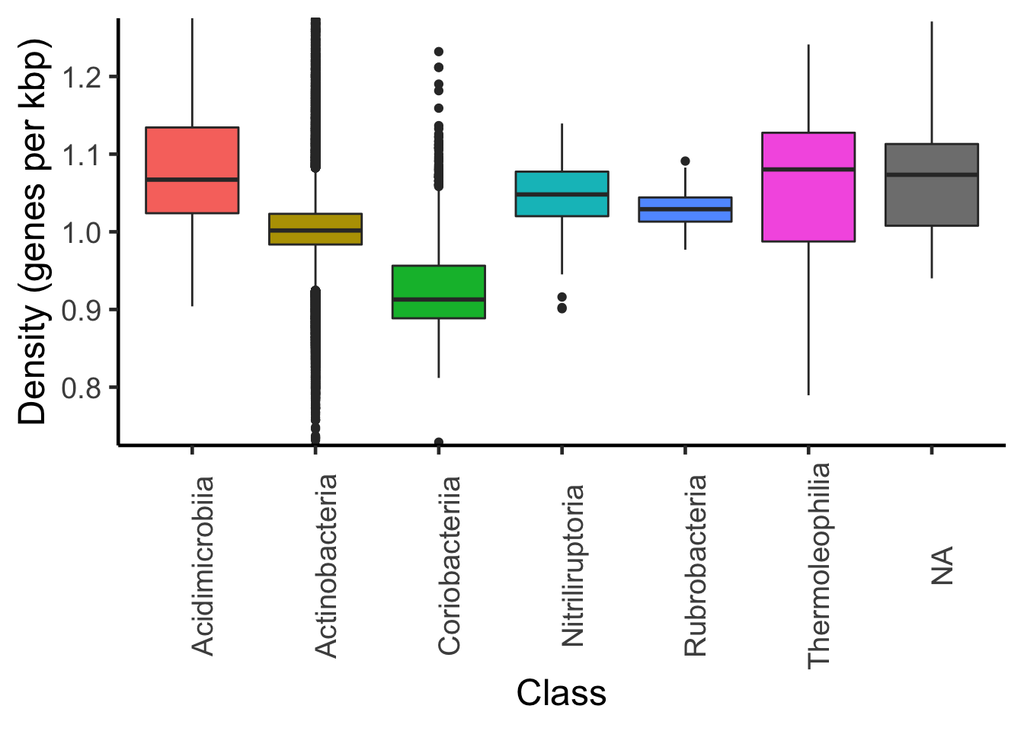

Figure 10. Gene density in Actinobacteria.

Info-Box!

Adding captions and exporting figures:

1. **Figure captions in .Rmd** – When creating graphs in an R Markdown (.Rmd) file, figures appear directly below the code chunk that produces them. Captions should be added within the chunk options using `fig.cap`. This automatically places a caption below the figure in the rendered document and allows figures to be numbered and referenced consistently. A good caption includes a short title and a brief description so the figure can stand alone.
2. **Exporting a single figure with `ggsave()`** – If you need to save a figure separately (e.g., to save a figure for a presentation or a paper), you can use the `ggsave()` function from the **ggplot2** package (part of the tidyverse). This function saves the most recent plot, or a specified plot object, directly to a file such as .png or .pdf. You can also control the size and resolution of the exported figure to meet specific formatting requirements.

**Great Work!**

This activity was adapted from the [Biostatistics using R: A Laboratory Manual](https://qubeshub.org/publications/2213/supportingdocs/1) by Raisa Hernández-Pacheco and Alexis A Diaz of California State University, Long Beach by Jenna T. B. Ekwealor for San Francisco State University.

This work is licensed under a [Creative Commons Attribution-ShareAlike 4.0 International License](http://creativecommons.org/licenses/by-sa/4.0/).

[← Previous Chapter](https://jenna-tb-ekwealor.github.io/Biostatistics_laboratory/Ch2.html)

[Next Chapter →](https://jenna-tb-ekwealor.github.io/Biostatistics_laboratory/Ch4.html)

[Home](https://jenna-tb-ekwealor.github.io/Biostatistics_laboratory/)